# Household Debt, Savings, and Unemployment: An OECD Panel Analysis

2026-09-09

## Load the Data

```r
getwd()
```

```
## [1] "/Users/evanbok/RProjects/R projects/hh_budget-project"
```

```r
list.files()
```

```
## [1] "hh_budget_git.html" "hh_budget_git.Rmd"  "hh_budget.csv"
## [4] "OECS budget.R"
```

```r
hh_budget <- read.csv("hh_budget.csv")
```

## Research Question 1: Did the 2008 financial crisis structurally change the relationship between household debt and savings behavior across OECD countries?

```r
library(tidyverse)
```

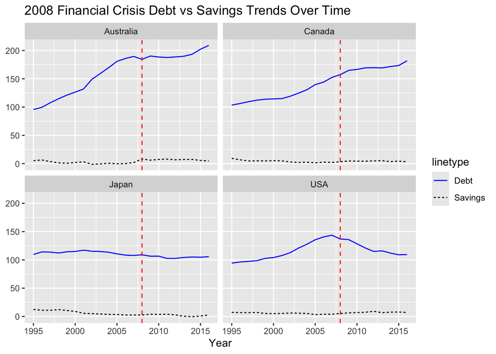

```r
#post2008 indicator for plot and model
hh_budget <- hh_budget |>
  mutate(post2008 = ifelse(Year >= 2008, 1, 0))

#Debt and Savings trends over time
ggplot(data=hh_budget, aes(x=Year)) +
  geom_line(aes(y=Debt, linetype="Debt"), color="blue") +
  geom_line(aes(y=Savings, linetype="Savings")) +
  geom_vline(xintercept = 2008, color="red", linetype="dashed") +
  facet_wrap(~Country) +
  labs(title="2008 Financial Crisis Debt vs Savings Trends Over Time", y=NULL)
```

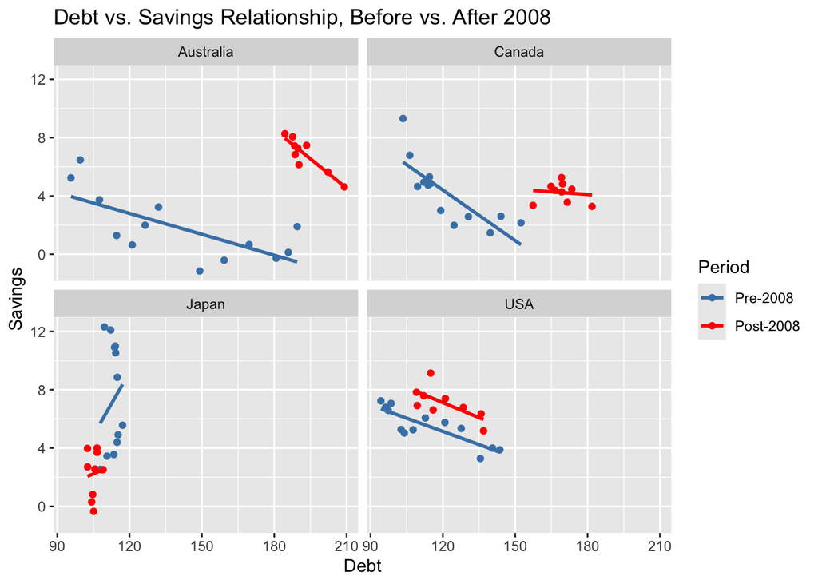

```r
#Debt and Savings relationship, before vs. after 2008
ggplot(hh_budget, aes(x=Debt, y=Savings, color=factor(post2008))) +
  geom_point() +
  geom_smooth(method="lm", se=FALSE) +
  facet_wrap(~Country) +
  labs(title="Debt vs. Savings Relationship, Before vs. After 2008",
       color="Period", x="Debt", y="Savings") +
  scale_color_manual(values=c("0"="steelblue", "1"="red"),
                      labels=c("Pre-2008", "Post-2008"))
```

```r
#Model to test how Debt's relationship with Savings changes before and after 2008
model_structural <- lm(Savings ~ Debt * post2008, data = hh_budget)
summary(model_structural)
```

```
##
## Call:
## lm(formula = Savings ~ Debt * post2008, data = hh_budget)
##
## Residuals:
##     Min      1Q  Median      3Q     Max
## -4.5575 -1.6630 -0.2513  1.0465  6.5796
##
## Coefficients:
##                Estimate Std. Error t value Pr(>|t|)
## (Intercept)    14.98477    1.84813   8.108 3.69e-12 ***
## Debt           -0.08441    0.01485  -5.685 1.85e-07 ***
## post2008      -13.02773    2.50446  -5.202 1.37e-06 ***
## Debt:post2008   0.10585    0.01858   5.696 1.76e-07 ***
## ---
## Signif. codes:  0 '***' 0.001 '**' 0.01 '*' 0.05 '.' 0.1 ' ' 1
##
## Residual standard error: 2.426 on 84 degrees of freedom
## Multiple R-squared:  0.3043, Adjusted R-squared:  0.2794
## F-statistic: 12.25 on 3 and 84 DF,  p-value: 1.006e-06
```

## Research Question 2: Is there a lagged relationship between household debt levels and unemployment — does rising debt predict unemployment increases 1–2 years later, or is causality more likely reversed?

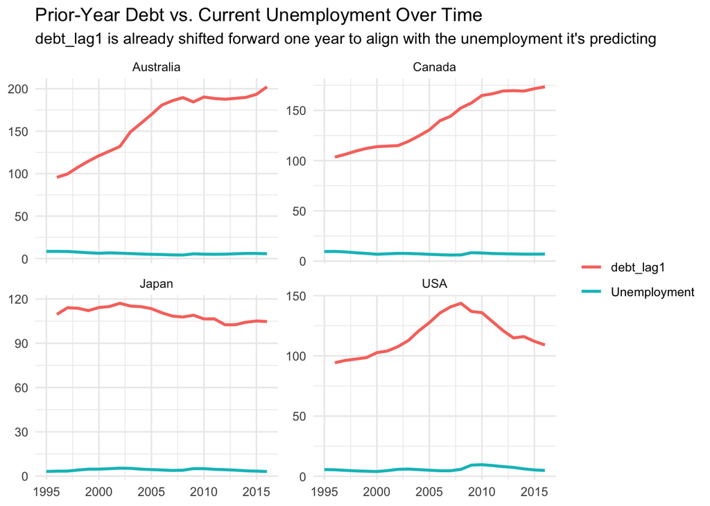

```r
#Create a df that shows a side-by-side comparison of current year debt compared to debt to the previous two years
  #This code shows a wide table showing debt from the previous two years (debt_lag1 and debt_lag2) - we use this to feed into our regression model because models want each variable as its own column
hh_lagged <- hh_budget |>
  arrange(Country, Year) |>
  group_by(Country) |>
  mutate(debt_lag1 = lag(Debt, 1),
         debt_lag2 = lag(Debt, 2)) |>
  ungroup()

#This code shows a long table showing debt from one year ago (debt_lag1) - we use the long format to be able to create a ggplot chart because color=variable and geom_line() want one row per line per point (easier to plot two lines with different colors like this)
hh_lagged_long <- hh_lagged |>
  select(Country, Year, debt_lag1, Unemployment) |>
  pivot_longer(cols = c(debt_lag1, Unemployment),
    names_to = "variable", values_to = "value")

#NOTE: wide for modeling, long for plotting
ggplot(hh_lagged_long, aes(x = Year, y = value, color = variable)) +
  geom_line(linewidth = 1) +
  facet_wrap(~ Country, scales = "free_y") +
  labs(title = "Prior-Year Debt vs. Current Unemployment Over Time",
       subtitle = "debt_lag1 is already shifted forward one year to align with the unemployment it's predicting",
       x = NULL, y = NULL, color = NULL) +
  theme_minimal()
```

```r
#Model to test the relationship between household debt levels and unemployment
model_lag<-lm(Unemployment ~ debt_lag1+debt_lag2, data=hh_lagged)
summary(model_lag)
```

```
##
## Call:
## lm(formula = Unemployment ~ debt_lag1 + debt_lag2, data = hh_lagged)
##
## Residuals:
##     Min      1Q  Median      3Q     Max
## -2.5748 -1.1164 -0.4389  1.0183  3.6708
##
## Coefficients:
##             Estimate Std. Error t value Pr(>|t|)
## (Intercept)  4.86868    0.78145   6.230 2.29e-08 ***
## debt_lag1   -0.01161    0.03883  -0.299    0.766
## debt_lag2    0.01940    0.03991   0.486    0.628
## ---
## Signif. codes:  0 '***' 0.001 '**' 0.01 '*' 0.05 '.' 0.1 ' ' 1
##
## Residual standard error: 1.532 on 77 degrees of freedom
##   (8 observations deleted due to missingness)
## Multiple R-squared:  0.02262,    Adjusted R-squared:  -0.002766
## F-statistic: 0.8911 on 2 and 77 DF,  p-value: 0.4144
```

```r
  #In the model above, Unemployment is the dependent variable and debt_lag1+debt_lag2 are the combined independent variables
  # debt_lag1 and debt_lag2 individually both have p-values greater than 0.05, which tells us that neither have a statistically significant relationships with unemployment
  # An R-squared of 0.023 is very low and tells us that debt_lag1 and debt_lag2 combined have almost no explanatory power on the changes in unemployment rate
  # An adjusted R-squared of -0.0028 (-0.28%) means the model is performing worse than a model with no predictors at all
  # The overall combined P-value of 0.41 tells us that debt_lag1 and debt_lag2 taken together, doesn't improve predicting unemployment rate. Since p-value>0.05, we fail to reject the null hypothesis that these have no real effect

#Now that we know that debt_lag1+debt_lag2 are not great predictors of unemployment rate, we can test the opposite -
  #Is unemployment rate a significant predictor of future debt?

#This code creates a df with unemployment lag
hh_lagged2 <- hh_budget |>
  arrange(Country, Year) |>
  group_by(Country) |>
  mutate(unemp_lag1=lag(Unemployment,1)) |>
  ungroup()

#Here is our model measuring the significance of impact that unemployment has on predicting future debt
model_reverse <- lm(Debt ~ unemp_lag1, data=hh_lagged2)
summary(model_reverse)
```

```
##
## Call:
## lm(formula = Debt ~ unemp_lag1, data = hh_lagged2)
##
## Residuals:
##    Min     1Q Median     3Q    Max
## -37.32 -23.97 -16.36  26.22  75.05
##
## Coefficients:
##             Estimate Std. Error t value Pr(>|t|)
## (Intercept)   127.77      12.95   9.867 1.37e-15 ***
## unemp_lag1      1.03       2.09   0.493    0.623
## ---
## Signif. codes:  0 '***' 0.001 '**' 0.01 '*' 0.05 '.' 0.1 ' ' 1
##
## Residual standard error: 31.62 on 82 degrees of freedom
##   (4 observations deleted due to missingness)
## Multiple R-squared:  0.002953,   Adjusted R-squared:  -0.009206
## F-statistic: 0.2428 on 1 and 82 DF,  p-value: 0.6235
```

```r
  #unemp_lag1 has a P-value of 0.623, meaning it is not a significant predictor of debt
  # R-squared is 0.00295(0.295%), is lower than the original model but is still very low and tells us that unemployment rate has almost no explanatory power in determining debt
  # Adjusted R-squared of -0.00921(-0.921%) means the model performs slightly worse than with no predictors at all
```

**Findings:** Neither direction shows a statistically significant relationship in this data. Debt doesn’t significantly predict future unemployment, and unemployment doesn’t significantly predict future debt. This suggests that in this dataset and time frame, debt and unemployment don’t have a strong causal relationship in either direction — any relationship between the two may be driven by a third factor. The null result doesn’t completely rule out a relationship between debt and unemployment — it’s possible their relationship is non-linear, driven by a third factor (e.g., macroeconomic shocks), or that the sample size of 4 countries lacks the power to detect significant effects.

## Research Question 3: Does household wealth help explain why some countries’ spending stays stable when income changes, while other countries’ spending closely tracks income ups and downs?

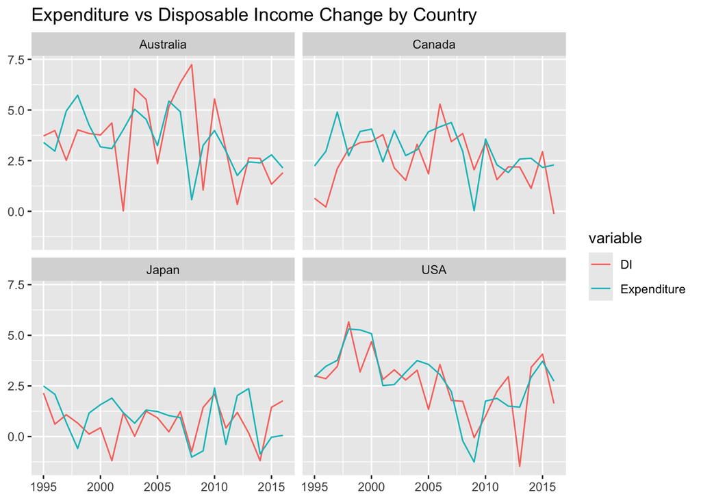

```r
#need to make the df long to plot the graph
hh_long <- hh_budget |>
  select(Year, Country, Expenditure, DI) |>
  pivot_longer(cols=c(Expenditure, DI), names_to="variable", values_to="value")

#graph
ggplot(hh_long, aes(x=Year, y=value, color=variable))+
  geom_line()+
  facet_wrap(~Country)+
  labs(title="Expenditure vs Disposable Income Change by Country", x=NULL, y=NULL)
```

```r
#this code calculates a correlation coefficient for each country, telling us how closely Expenditure tracks DI over time.
  #Correlation values near 1 mean spending closely tracks income changes, values near 0 means spending stays more stable despite income changes.
#It is also representative of the graph above
hh_budget |>
  group_by(Country) |>
  summarize(
    income_exp_correlation = cor(DI, Expenditure),
    avg_wealth = mean(Wealth)
  ) |>
  arrange(desc(avg_wealth))
```

```
## # A tibble: 4 × 3
##   Country   income_exp_correlation avg_wealth
##   <chr>                      <dbl>      <dbl>
## 1 USA                        0.720       529.
## 2 Japan                      0.277       515.
## 3 Canada                     0.358       462.
## 4 Australia                  0.246       359.
```

```r
#Model: This tests whether DI and Wealth independently effect Expenditure and the research question - whether Wealth changes the strength of DI's effect on Expenditure
model_smoothing <- lm(Expenditure~DI*Wealth, data = hh_budget)
summary(model_smoothing)
```

```
##
## Call:
## lm(formula = Expenditure ~ DI * Wealth, data = hh_budget)
##
## Residuals:
##     Min      1Q  Median      3Q     Max
## -3.4090 -0.5460  0.0180  0.6207  2.3911
##
## Coefficients:
##               Estimate Std. Error t value Pr(>|t|)
## (Intercept)  5.5196631  1.3300885   4.150 7.93e-05 ***
## DI          -0.6596439  0.3904771  -1.689  0.09487 .
## Wealth      -0.0087552  0.0026768  -3.271  0.00156 **
## DI:Wealth    0.0025726  0.0008397   3.064  0.00294 **
## ---
## Signif. codes:  0 '***' 0.001 '**' 0.01 '*' 0.05 '.' 0.1 ' ' 1
##
## Residual standard error: 1.207 on 84 degrees of freedom
## Multiple R-squared:  0.4554, Adjusted R-squared:  0.4359
## F-statistic: 23.41 on 3 and 84 DF,  p-value: 4.158e-11
```

```r
  #Expenditure is the dependent variable, DI and Wealth are both the independent variables
  #We use DI*Wealth so shows results for DI, Wealth, and DI:Wealth together
  #DI has a p-value of 0.09486 above the 0.05 threshold, so we fail to reject the null. Wealth has a p-value of 0.00156 making it significant. DI:Wealth is 0.00294 also making it statistically significant.
  #The model was a whole is a moderately strong predictor of Expenditure, with a R-squared of 0.4554 and p-value of 4.158e-11.
    #The significant interaction confirms that DI's effect on Expenditure depends on Wealth (strengthens as Wealth increases)
```

**Findings** Wealth and the DI:Wealth interaction are statistically significant predictors of Expenditure, while DI alone is only marginal (p=0.095). The model explains a moderate share of Expenditure’s variation (R-squared=0.4554, p=4.158e-11). Additionally, the significant positive interaction shows that DI’s effect on Expenditure grows stronger, not weaker, as Wealth increases — the opposite of the original hypothesis that wealth smooths spending against income shocks. This is consistent with the per-country correlation table: the USA, the wealthiest country in the sample, shows the strongest DI-Expenditure correlation (0.72), while lower-wealth Australia shows the weakest (0.25). Taken together, these results suggest that in this dataset, wealth does not buffer spending from income volatility — if anything, greater wealth is associated with spending that tracks income more closely, not less.